# Exercise Behavior and Prediction

Dahyr J. Vergara Suárez

Friday, September 19, 2014

### Executive Summary

Personal computers, smartphones, tablets and even TV’s have reached a really high level of functionality to what can be done by interacting with the screen. Digital services like cloud storage, market places, music and video are also reaching elevate maturity levels regarding web and mobile interaction functionality. All of this makes it really important for service and content providers to understand what users do to get more information, and this reveals the importance of new sources of information such as: how people move, what are their actual schedules, what affects their daily routines, just to name a few.

This study’s goal is to understand how people exercise, and specificaily what kind of exercise are they doing when performing weight lifting. To do this the **Weight Lifting Exercises Dataset** is used (Read more: http://groupware.les.inf.puc-rio.br/har#literature#ixzz3DxMnRITt), in it there are the following classes (variable classe): - Dumbbell Biceps Curl in five different fashions: exactly according to the specification (Class A) - Throwing the elbows to the front (Class B) - Lifting the dumbbell only halfway (Class C) - Lowering the dumbbell only halfway (Class D) - Throwing the hips to the front (Class E)

### Data Gathering & Exploration

The first thing to do is to get and clean the dataset. The data variables were transformed to use only the month, the weekday and the hour. For the rest of the variables it was necessary to review which of them had blank spaces or special characters and then convert them to numeric values.

In the end, the whole dataset contained only one categorical variable (classe) and the other remaining variables (predictors) were all numeric.

```
##              # Obs. # Vars.
## Testing Set      20     160
## Training Set  19622     160
```

[output not shown]

Now let’s remove all those variables that have near zero variance and then use principal component analysis (PCA) with thresholds of 70, 80 and 90% of variance to find a good number of variables to use in our predictions. With 70% variance we can use 14, for 80% 21 and to obtain variance of 90% 34 variables would be needed.

```r
## Variance analysis
# Subsetting again to exclude those variables with near zero variance
nzv <- nearZeroVar(training, saveMetrics = T)
training <- training[, rownames(nzv)[!nzv$nzv]]

pp70 <- preProcess(training[, -119], method = "pca", thresh = 0.7)
pp80 <- preProcess(training[, -119], method = "pca", thresh = 0.8)
pp90 <- preProcess(training[, -119], method = "pca", thresh = 0.9)

pcaComps <- as.data.frame(c(pp70$numComp, pp80$numComp, pp90$numComp))
names(pcaComps) <- c("# Components")
rownames(pcaComps) <- c("70% Variation", "80% Variation", "90% Variation")
pcaComps
```

```
##               # Components
## 70% Variation           14
## 80% Variation           21
## 90% Variation           34
```

```r
#qplot(predpca90[, 1], predpca90[, 2], col = training$classe)
```

The next thing to do is try to predict using random forests.

```r
rf <- train(classe ~ ., data = training, method = "rf",
            prox = T, importance = T)
rfx3 <- train(classe ~ ., data = training, method = "rf",
              ntree = 1500, prox = T)

rfpca <- train(classe ~ ., data = training, method = "rf", preProcess = "pca",
               prox = T, thresh = 0.9)
```

[output not shown]

```r
topImportanceRf <- importance(rf$finalModel)[, c(6, 7)]

head(topImportanceRf[order(-topImportanceRf[, 2]), ], 5)
```

```
##                    MeanDecreaseAccuracy MeanDecreaseGini
## avg_roll_dumbbell                 23.27           12.139
## var_roll_belt                     17.78           11.004
## stddev_roll_belt                  16.67           10.305
## var_accel_dumbbell                21.01            9.748
## pitch_forearm                     15.50            7.086
```

Resampling is done within the implementation of the random forests algorithm (by default it uses 500 trees and 25 reps).

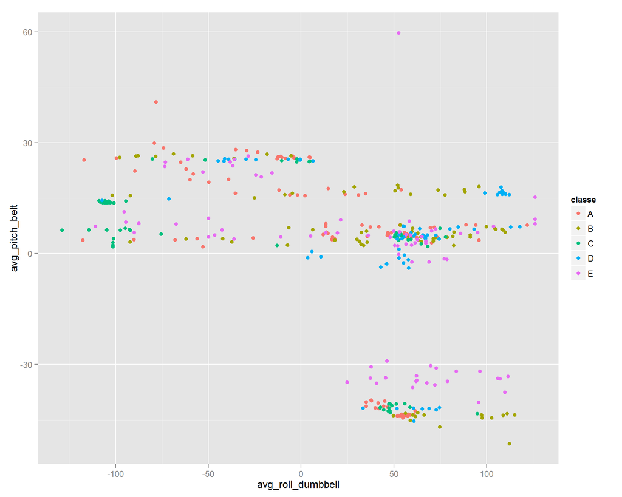

```r
qplot(avg_roll_dumbbell, avg_pitch_belt, color = classe, data = training)
```

19622 samples 121 predictors 5 classes: ‘A’, ‘B’, ‘C’, ‘D’, ‘E’

No pre-processing Resampling: Bootstrapped (25 reps)

Summary of sample sizes: 217, 217, 217, 217, 217, 217, …

Accuracy was used to select the optimal model using the largest value. The final value used for the model was mtry = 2.

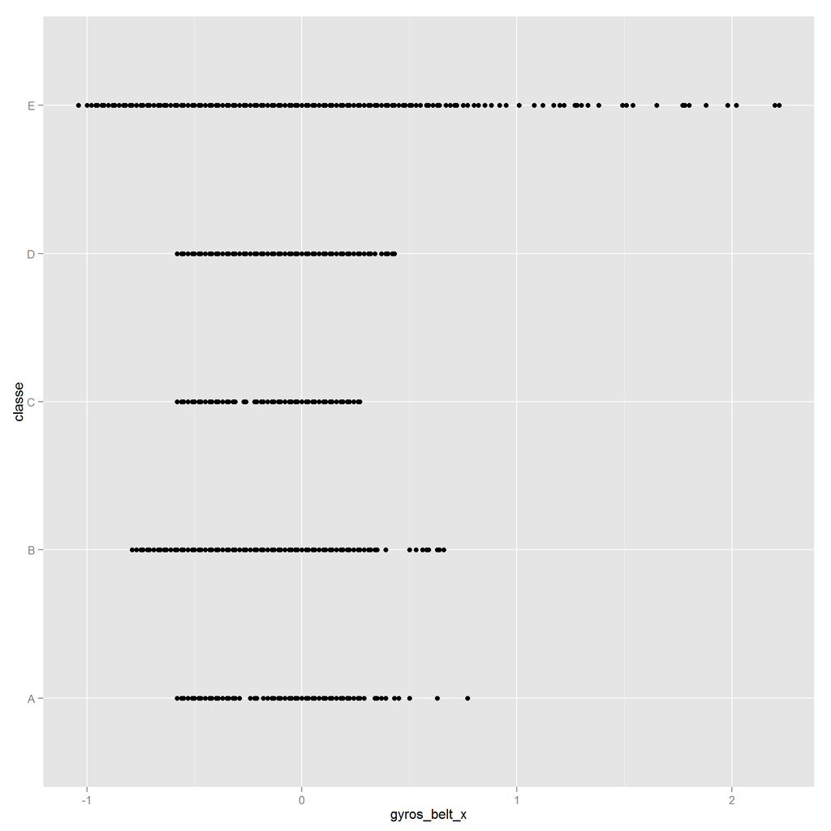

```r
qplot(gyros_belt_x, classe, data = training)
```